# Team NYData Miner

### Group:

Charles Mournet: charles.mournet@baruchmail.cuny.edu  
Farwa Ismail: farwa.ismail@baruchmail.cuny.edu  
John Akhras: john.akhras@baruchmail.cuny.edu  
Yen-Ching Lin: yenching.lin@baruchmail.cuny.edu  
Nandita Suresh Pai: nandita.sureshpai@baruchmail.cuny.edu

### Introduction

Predicting how the stock market will perform is a popular issue for wall street and individual investors. In general, stock market analysis is divided into two parts – Fundamental Analysis and Technical Analysis. Fundamental Analysis involves analyzing the company’s future profitability on the basis of economic and financial factors. These factors include economic and industry conditions, the effectiveness of the company's management, and a range of financial metrics. On the other hand, Technical Analysis uses historical market data such as price and volume, to identify the trends in the stock market.

### 1. Exploratory Data Analysis

```python
#load packages
%matplotlib inline
import os
import pandas as pd
import numpy as np
import seaborn as sns ## for plots
import matplotlib.pyplot as plt
import datetime
from sklearn import tree
from sklearn import preprocessing
from sklearn.linear_model import LogisticRegression
from sklearn.tree import DecisionTreeClassifier, DecisionTreeRegressor
from sklearn.model_selection import train_test_split
from sklearn.naive_bayes import GaussianNB
from sklearn.ensemble import RandomForestClassifier
from sklearn.metrics import accuracy_score, recall_score, precision_score, f1_score, roc_curve, auc
from dmba import plotDecisionTree, classificationSummary, regressionSummary
```

```python
# To grab stock data
import yfinance as fyf
from pandas_datareader import data as pdr
fyf.pdr_override() # <-- Here is the fix

#install packages pandas-datareader and yfinance if neccessary
```

```python
# Set label
stocks = ["INTC","MSFT","AMD","IBM"] # If you want to grab multiple stocks add more labels to this list

# Set start and end dates
start = datetime.datetime(1980, 3, 17)
end   = datetime.datetime(2020, 11, 8)

# Grab data
data = pdr.get_data_yahoo(stocks, start = start, end = end)
```

```
[*********************100%***********************]  4 of 4 completed
```

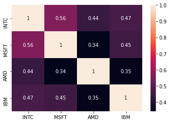

```python
#Correlation Matrix
df2 = pd.DataFrame({(s): data['Close'][s] for s in stocks}) #Pulled from raw data
df2 = df2.pct_change()[1:]
df2 = df2.dropna()
sns.heatmap(df2.corr(), annot = True)
```

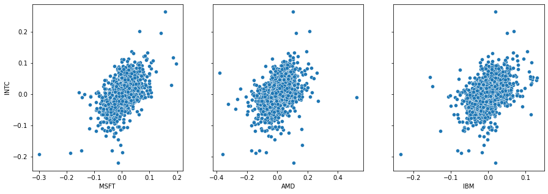

```python
#Scatter plot
fig, (ax1, ax2,ax3) = plt.subplots(ncols=3, sharey=True,figsize = (15,5))
sns.scatterplot(data=df2, x='MSFT',y='INTC',ax=ax1)
sns.scatterplot(data=df2, x='AMD',y='INTC', ax=ax2)
sns.scatterplot(data=df2, x='IBM',y='INTC', ax=ax3)
```

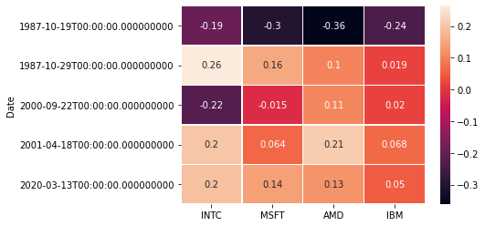

```python
#Outliers
df2_outliers = df2[(df2['INTC']>0.19) | (df2['INTC']<-0.19)]
ax = sns.heatmap(df2_outliers, annot = True,linewidths=.5)
```

Our goal for this classifier can be summarised as follows:

**We would like to predict if INTC's stock price (averaged over the next 30 days) will go up.**

#### Predictors

In this vein, we would also like suitable predictors. Just using daily closing prices are inadequate for a general machine learning problem. We can provide more information per data point, by adding in rolling averages of differing window lengths. This will allow models to be able to take in information about recent stock trends to predict the movement of the stock over the next 30 days.

However, using just rolling average values can allow the algorithm to overfit, by learning to associate absolute stock values with points in time (over 20 years stocks prices are monotonically increasing). We would rather the algorithm learn to reason based on trends.

We define our predictors as follows:

Let $S_t$ be the stock price on day $t$, and $R_m(S_t)$ be the $m$-day rolling average of the the stock price as of day $t$

Then we define our new features $K_t$:

$$ K_t = \frac{R_m(S_t)-S_{t-m}}{S_{t-m}} $$

For example: `INTC_rolling_7` is the fractional difference between `INTC`'s average stock price over the last 7 days, and `INTC`'s stock price 7 days ago.

```python
#We use lags of 1,7,14 and 30 days
lags = [0,1,7,14,30]

#Fractional Rolling Averages
df = pd.DataFrame({(s+'_rolling'+str(l)): (data['Close'][s].rolling(l+1).mean() - data['Close'][s].shift(l))/(data['Close'][s].shift(l)) for l in lags for s in stocks})

#Average of next 30 days of trading
df['Price_Up'] = (data['Close']["INTC"].shift(-1).rolling(30).mean().shift(-29)-data['Close']["INTC"] > 0)

#We drop all the rows that have nulls (since MSFT is the only stock not present in early 1980s)
df = df.dropna()
df = df.drop([stock+'_rolling0' for stock in stocks],axis=1)


def normalize_columns(df):
    vals = df.values
    return pd.DataFrame(preprocessing.MinMaxScaler().fit_transform(vals),index=df.index,columns=df.columns)

#We will normalize the columns before processing
df = normalize_columns(df)
df['Price_Up'] = df['Price_Up'].astype('bool')
```

```python
## Dataframe Insights
print('Shape:')
print(df.shape)
print('')
print('Column Titles:')
print(df.columns)
print('')
print('Date Range: ')
print(df.index[0].date(), 'to', df.index[-1].date())
```

```
Shape:
(8707, 17)

Column Titles:
Index(['INTC_rolling1', 'MSFT_rolling1', 'AMD_rolling1', 'IBM_rolling1',
       'INTC_rolling7', 'MSFT_rolling7', 'AMD_rolling7', 'IBM_rolling7',
       'INTC_rolling14', 'MSFT_rolling14', 'AMD_rolling14', 'IBM_rolling14',
       'INTC_rolling30', 'MSFT_rolling30', 'AMD_rolling30', 'IBM_rolling30',
       'Price_Up'],
      dtype='object')

Date Range:
1986-04-25 to 2020-11-06
```

```python
#Target Variable
print('Target Variable Total Instances')
print(df['Price_Up'].count())
print('Days stock price went up:')
print(df['Price_Up'].sum())
print('Days stock price went down:')
print((df['Price_Up'].count())-(df['Price_Up'].sum()))
#df.Price_Up.value_counts()
```

```
Target Variable Total Instances
8707
Days stock price went up:
4987
Days stock price went down:
3720
```

```python
#Missing Values and Duplicates
print(df.isna().sum())
print("Duplicates count: ",df.duplicated().sum())
```

```
INTC_rolling1     0
MSFT_rolling1     0
AMD_rolling1      0
IBM_rolling1      0
INTC_rolling7     0
MSFT_rolling7     0
AMD_rolling7      0
IBM_rolling7      0
INTC_rolling14    0
MSFT_rolling14    0
AMD_rolling14     0
IBM_rolling14     0
INTC_rolling30    0
MSFT_rolling30    0
AMD_rolling30     0
IBM_rolling30     0
Price_Up          0
dtype: int64
Duplicates count:  0
```

```python
#Display a snippet of the dataset
df.head()
```

| Date | INTC_rolling1 | MSFT_rolling1 | AMD_rolling1 | IBM_rolling1 | INTC_rolling7 | MSFT_rolling7 | AMD_rolling7 | IBM_rolling7 | INTC_rolling14 | MSFT_rolling14 | AMD_rolling14 | IBM_rolling14 | INTC_rolling30 | MSFT_rolling30 | AMD_rolling30 | IBM_rolling30 | Price_Up |
| --- | --- | --- | --- | --- | --- | --- | --- | --- | --- | --- | --- | --- | --- | --- | --- | --- | --- |
| 1986-04-25 | 0.541916 | 0.732977 | 0.429471 | 0.673571 | 0.482748 | 0.571085 | 0.404014 | 0.472420 | 0.671941 | 0.649933 | 0.423097 | 0.454380 | 0.421906 | 0.476874 | 0.305588 | 0.387808 | False |
| 1986-04-28 | 0.438466 | 0.621093 | 0.397986 | 0.673190 | 0.495260 | 0.589615 | 0.418991 | 0.490856 | 0.610973 | 0.661706 | 0.409179 | 0.427860 | 0.473780 | 0.435380 | 0.370231 | 0.393310 | False |
| 1986-04-29 | 0.387949 | 0.546982 | 0.392942 | 0.607357 | 0.530227 | 0.694668 | 0.416368 | 0.542038 | 0.641254 | 0.650573 | 0.419235 | 0.477869 | 0.477756 | 0.417286 | 0.307588 | 0.390841 | False |
| 1986-04-30 | 0.368333 | 0.560437 | 0.378154 | 0.587690 | 0.530227 | 0.723640 | 0.402638 | 0.506192 | 0.527166 | 0.651481 | 0.375308 | 0.469255 | 0.467353 | 0.459012 | 0.311002 | 0.375586 | False |
| 1986-05-01 | 0.473244 | 0.574977 | 0.439954 | 0.652048 | 0.502410 | 0.790464 | 0.411772 | 0.548253 | 0.501601 | 0.632526 | 0.364667 | 0.483812 | 0.494371 | 0.490007 | 0.327876 | 0.385831 | False |

### 2. Baseline Models

We assume given the random walk nature of stocks the baseline for our model is to improve from a random guess. If the stock goes up half the days and down half the days the outcome of just guessing over time would be 0.5. The goal of our baseline models is too improve upon this, and select the best outcome models to optimize.

#### Train-test split

Here, we perform a train-test split so we can make sure that the tests we create to test the accuracy of our machine learning models are based on examples that the model has not seen before. We perform a $70 \% - 30 \%$ split.

Often one randomizes the ordering of the dataset before splitting, to make sure that the algorithm doesn't reason based on the ordering of the data. However, in time-series data the ordering of the data is very important, and we must be careful not to randomize. Time series data is often continuous in time and that is a constraint that can give too much information to a machine learning model.

Consider a train test split where the training points and testing points are interspersed between each other, then the machine learning algorithm can very well overfit on the training set, memorize the data points and learn to simply interpolate values. This is an example of **leaking**.

We avoid this by making a simple $70\% - 30\%$ split based on a particular cutoff date. All datapoints that occur after that date are in the test set, all the ones before are part of the training set. This prevents data-leaking.

```python
#70-30 Train-Test split. The split is done about a particular date which splits our data into a 70% piece and a 30% piece.
#No randomization since it is a Time-series dataset

#Normalization
Train = df.iloc[:int(len(df.index)*0.7),:]
Test = df.iloc[int(len(df.index)*0.7 + 1):,:]
X_train = Train.drop('Price_Up',axis=1);
X_test = Test.drop('Price_Up',axis=1);
y_train = Train['Price_Up'];
y_test = Test['Price_Up'];

X_train.head()
```

| Date | INTC_rolling1 | MSFT_rolling1 | AMD_rolling1 | IBM_rolling1 | INTC_rolling7 | MSFT_rolling7 | AMD_rolling7 | IBM_rolling7 | INTC_rolling14 | MSFT_rolling14 | AMD_rolling14 | IBM_rolling14 | INTC_rolling30 | MSFT_rolling30 | AMD_rolling30 | IBM_rolling30 |
| --- | --- | --- | --- | --- | --- | --- | --- | --- | --- | --- | --- | --- | --- | --- | --- | --- |
| 1986-04-25 | 0.541916 | 0.732977 | 0.429471 | 0.673571 | 0.482748 | 0.571085 | 0.404014 | 0.472420 | 0.671941 | 0.649933 | 0.423097 | 0.454380 | 0.421906 | 0.476874 | 0.305588 | 0.387808 |
| 1986-04-28 | 0.438466 | 0.621093 | 0.397986 | 0.673190 | 0.495260 | 0.589615 | 0.418991 | 0.490856 | 0.610973 | 0.661706 | 0.409179 | 0.427860 | 0.473780 | 0.435380 | 0.370231 | 0.393310 |
| 1986-04-29 | 0.387949 | 0.546982 | 0.392942 | 0.607357 | 0.530227 | 0.694668 | 0.416368 | 0.542038 | 0.641254 | 0.650573 | 0.419235 | 0.477869 | 0.477756 | 0.417286 | 0.307588 | 0.390841 |
| 1986-04-30 | 0.368333 | 0.560437 | 0.378154 | 0.587690 | 0.530227 | 0.723640 | 0.402638 | 0.506192 | 0.527166 | 0.651481 | 0.375308 | 0.469255 | 0.467353 | 0.459012 | 0.311002 | 0.375586 |
| 1986-05-01 | 0.473244 | 0.574977 | 0.439954 | 0.652048 | 0.502410 | 0.790464 | 0.411772 | 0.548253 | 0.501601 | 0.632526 | 0.364667 | 0.483812 | 0.494371 | 0.490007 | 0.327876 | 0.385831 |

### Decision Tree

Our first attempt at a baseline model is a decision tree. We start with this because not only is it simple and fast, but the interpretability of it's results *can* lend themselves to some insight.

```python
dt = tree.DecisionTreeClassifier(max_depth=6,random_state=0)
dt = dt.fit(X_train, y_train)

# predict probabilities
prediction_train = dt.predict(X_train)
prediction_valid = dt.predict(X_test)
```

```python
def AUCscore(y,pred):
    false_positives, true_positives, _ = roc_curve(y, pred)
    return auc(false_positives, true_positives)

def print_scores(prediction_train,prediction_valid,y_train,y_test):
    # Measuring the accuracy of the model for both train and test sets
    print("Accuracy on train is:",accuracy_score(y_train,prediction_train))
    print("Accuracy on test is:",accuracy_score(y_test,prediction_valid))

    #Measuring AUC:
    print("AUC on train is:",AUCscore(y_train, prediction_train))
    print("AUC on test is:",AUCscore(y_test, prediction_valid))

    # Measuring the precision of the model for both train and test sets
    print("Precision on train is:",precision_score(y_train,prediction_train))
    print("Precision on test is:",precision_score(y_test,prediction_valid))

    # Measuring the recall of the model for both train and test sets
    print("Recall on train is:",recall_score(y_train,prediction_train))
    print("Recall on test is:",recall_score(y_test,prediction_valid))

    # Measuring the f-measure of the model for both train and test sets
    print("f-measure on train is:",f1_score(y_train,prediction_train))
    print("f-measure on test is:",f1_score(y_test,prediction_valid))

print_scores(prediction_train,prediction_valid,y_train,y_test)
```

```
Accuracy on train is: 0.6316048572366262
Accuracy on test is: 0.531010719754977
AUC on train is: 0.5932253335286466
AUC on test is: 0.48025430460098334
Precision on train is: 0.6347714651858181
Precision on test is: 0.5552173913043478
Recall on train is: 0.8474479612204163
Recall on test is: 0.86342123056119
f-measure on train is: 0.7258517523507143
f-measure on test is: 0.6758401693569727
```

$53\%$ accuracy is better than a coin-flip, which means there definitely are *some* gains to be found over randomness. We also noticed by increasing `max_depth` that it is easy to overfit these models, which is what we expect from decision trees.

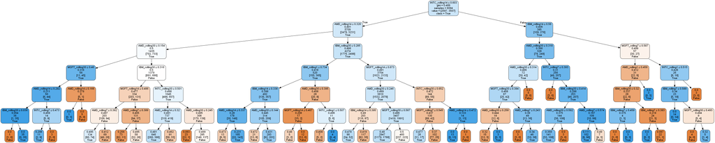

```python
plotDecisionTree(dt, feature_names=X_train.columns, class_names=dt.classes_, impurity = True)
```

The decision tree found the 14-day rolling average of Intel to be the top most node, which is an interesting choice, one would expect smaller time scales to matter more.

### Logistic Regression

Logistic regression is another simple model we can try, to increase our accuracy. We hypothesize that it may do better than the decision tree, since logistic regressions can take linear combinations of variables which can allow it to more readily find useful variable interactions. e.g. (the difference of two variables might be a useful predictor)

```python
log_reg = LogisticRegression(max_iter = 1000,random_state=0).fit(X_train, y_train)

# predict probabilities
prediction_train = log_reg.predict(X_train)
prediction_valid = log_reg.predict(X_test)

print_scores(prediction_train,prediction_valid,y_train,y_test)
```

```
Accuracy on train is: 0.5815556284870365
Accuracy on test is: 0.5650842266462481
AUC on train is: 0.5156690870288799
AUC on test is: 0.49960524125040956
Precision on train is: 0.5836392239119035
Precision on test is: 0.5660377358490566
Recall on train is: 0.9520958083832335
Recall on test is: 0.9939148073022313
f-measure on train is: 0.7236671001300389
f-measure on test is: 0.7212953876349362
```

Linear regression clearly did better on the test set.

### Naive Bayes

Naive bayes, is again a simple and extensible algorithm to run, and it's `coeff` parameter will tell us about how our constructed variables behave on average, given that the intel stock is going up or not. This can help us throw out useless features.

```python
nb = GaussianNB()
nb.fit(X_train, y_train)

# predict probabilities
prediction_train = nb.predict(X_train)
prediction_valid = nb.predict(X_test)

print_scores(prediction_train,prediction_valid,y_train,y_test)
```

```
Accuracy on train is: 0.5763045618641287
Accuracy on test is: 0.5535987748851455
AUC on train is: 0.5275849537878244
AUC on test is: 0.4947284937044483
Precision on train is: 0.5917840841436793
Precision on test is: 0.5634888438133874
Recall on train is: 0.8502994011976048
Recall on test is: 0.9391480730223124
f-measure on train is: 0.6978703487011467
f-measure on test is: 0.7043610547667343
```

```python
pd.DataFrame({'coeff': nb.theta_[1] - nb.theta_[0]}, index=X_train.columns).sort_values('coeff',ascending=False)
```

|  | coeff |
| --- | --- |
| INTC_rolling14 | 0.010451 |
| AMD_rolling14 | 0.009334 |
| AMD_rolling30 | 0.008686 |
| MSFT_rolling14 | 0.005742 |
| INTC_rolling30 | 0.005207 |
| MSFT_rolling7 | 0.003819 |
| INTC_rolling7 | 0.003417 |
| AMD_rolling7 | 0.002359 |
| MSFT_rolling1 | 0.000730 |
| AMD_rolling1 | 0.000007 |
| INTC_rolling1 | -0.000168 |
| IBM_rolling1 | -0.000721 |
| IBM_rolling14 | -0.001961 |
| IBM_rolling7 | -0.002847 |
| IBM_rolling30 | -0.005538 |
| MSFT_rolling30 | -0.006284 |

We see again, that `INTC_rolling14` is the most effective in determining our target variable.

### Random Forest

Random Forest is a great flexible and powerful model to use. We predict that it would do better than the decision tree, since it is simply an ensemble method over multiple decision trees.

```python
rf = RandomForestClassifier(max_depth=6,n_estimators=200,random_state=0)
rf.fit(X_train, y_train)

# predict probabilities
prediction_train = rf.predict(X_train)
prediction_valid = rf.predict(X_test)
```

```python
print_scores(prediction_train,prediction_valid,y_train,y_test)
```

```
Accuracy on train is: 0.6808336068263866
Accuracy on test is: 0.5681470137825421
AUC on train is: 0.6258565204341993
AUC on test is: 0.5058199315274091
Precision on train is: 0.6451133407655146
Precision on test is: 0.5691761923531731
Recall on train is: 0.9900199600798403
Recall on test is: 0.9763353617308993
f-measure on train is: 0.7811902351220609
f-measure on test is: 0.7191235059760958
```

The most accurate model so far is the Random forest classifier, and as predicted it was better than the decision tree. We will chose the Random Forest Classifier as our baseline model.

### Summary of Baseline Models

By comparing the baseline models accuracy on the training set we found the baseline models to have moderately hopeful results. The improvement above .5 is hopeful in indicating that the attributes of lagging price we have selected help offer some degree of insight about INTC stock price. From here the goal becomes to improve the accuracy beyond that of the baseline models.

### Selecting the most important features:

We use the random forest model's `feature_importances_` attribute to understand the importance of different features to the model. We will use this to narrow down the right variables for feature engineering in our later stages, and to get rid of features that do not add to the model's predictivness.

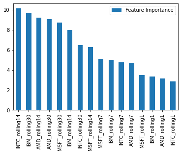

```python
imps = pd.DataFrame({'Feature Importance':rf.feature_importances_*100},index=X_train.columns).sort_values('Feature Importance',ascending=False)
imps.plot.bar()
plt.show()
```

These results are similar to those given by the Naive Bayes algorithm which strengthens our feeling that these features really are important for prediction.

We select the first 8 features since there is a sufficient drop off after the 8th feature.

```python
imp_cols = list(imps.iloc[:8].index)
print("The top most important columns are: ")
print(imp_cols)
df_imp = df[imp_cols+['Price_Up']]
```

```
The top most important columns are:
['INTC_rolling14', 'IBM_rolling30', 'AMD_rolling14', 'AMD_rolling30', 'MSFT_rolling30', 'IBM_rolling14', 'INTC_rolling30', 'MSFT_rolling14']
```

We create the train test split again, but this time keep only the important columns

```python
Train_imp = df_imp.iloc[:int(len(df_imp.index)*0.7),:]
Test_imp = df_imp.iloc[int(len(df_imp.index)*0.7 + 1):,:]
X_train_imp = Train_imp.drop('Price_Up',axis=1);
X_test_imp = Test_imp.drop('Price_Up',axis=1);
y_train_imp = Train_imp['Price_Up'];
y_test_imp = Test_imp['Price_Up'];
```

## 3. Feature Engineering

#### Kmeans

One thing we can try is using Kmeans to find clusters inside the important features we have found. These can create categorical variables that might help our previous methods like Decision trees and Random Forests become more accurate.

```python
from sklearn.cluster import KMeans

kmeans = KMeans(n_clusters=6, random_state=0).fit(X_train[imp_cols]) #Clusters based on the training set

df_km = df_imp.copy();
df_km.loc[:,'Cluster'] = kmeans.predict(df_km[imp_cols])
#print(df_imp)
#Use dummy encoding to get new values
df_km = df_km.join(pd.get_dummies(df_km['Cluster'],prefix='Cluster'))
df_km = df_km.drop('Cluster',axis=1)
cluster_cols = ['Cluster_'+ str(a) for a in range(kmeans.n_clusters)]

Trainkm = df_km.iloc[:int(len(df_km.index)*0.7),:]
Testkm = df_km.iloc[int(len(df_km.index)*0.7 + 1):,:]
X_train_Cluster = Trainkm.drop('Price_Up',axis=1);
X_test_Cluster = Testkm.drop('Price_Up',axis=1);

#print(X_train)
X_test_Cluster[cluster_cols]
```

| Date | Cluster_0 | Cluster_1 | Cluster_2 | Cluster_3 | Cluster_4 | Cluster_5 |
| --- | --- | --- | --- | --- | --- | --- |
| 2010-06-25 | 1 | 0 | 0 | 0 | 0 | 0 |
| 2010-06-28 | 1 | 0 | 0 | 0 | 0 | 0 |
| 2010-06-29 | 1 | 0 | 0 | 0 | 0 | 0 |
| 2010-06-30 | 0 | 0 | 0 | 0 | 0 | 1 |
| 2010-07-01 | 0 | 0 | 0 | 0 | 0 | 1 |
| ... | ... | ... | ... | ... | ... | ... |
| 2020-11-02 | 0 | 0 | 0 | 0 | 0 | 1 |
| 2020-11-03 | 0 | 0 | 0 | 0 | 0 | 1 |
| 2020-11-04 | 0 | 0 | 0 | 0 | 0 | 1 |
| 2020-11-05 | 0 | 0 | 0 | 0 | 0 | 1 |
| 2020-11-06 | 0 | 0 | 0 | 0 | 0 | 1 |

2612 rows × 6 columns

#### PCA (Principal Component Analysis)

PCA can allow to us to find linear combinations of the current variables to give us better variables that represent the dataset. This will only work for continuous variables.

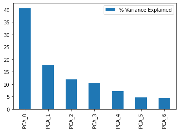

```python
from sklearn.decomposition import PCA

pca = PCA(0.95,random_state=0)
pca.fit(X_train[imp_cols])

pd.DataFrame({'% Variance Explained':100*pca.explained_variance_ratio_},index=['PCA_'+str(i) for i in range(len(pca.explained_variance_ratio_))]).plot.bar()
plt.show()
```

```python
#Train test split with PCA columns
X_train_PCA = pd.DataFrame(pca.transform(X_train[imp_cols]),index=X_train.index).add_prefix('PCA_')
X_test_PCA = pd.DataFrame(pca.transform(X_test[imp_cols]),index=X_test.index).add_prefix('PCA_')
df_PCA_full = df[imp_cols + ['Price_Up']].join(pd.DataFrame(pca.transform(df[imp_cols]),index=df.index).add_prefix('PCA_'))
```

```python
#Train test split with PCA and Cluster columns both
X_train_fe = X_train_PCA.join(X_train_Cluster[cluster_cols])
X_test_fe = X_test_PCA.join(X_test_Cluster[cluster_cols])
```

Let's also examine the correlation b/w first two PCA variables and the k-means clustering:

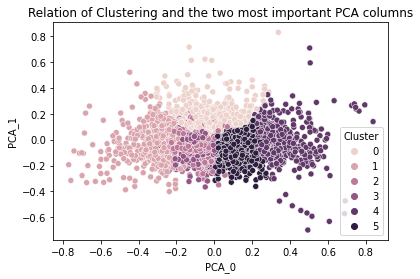

```python
import seaborn as sns
X_train_fe_Cluster = X_train_fe.copy()
X_train_fe_Cluster['Cluster'] = pd.Series(kmeans.predict(X_train[imp_cols]),index=X_train.index)
sns.scatterplot(data=X_train_fe_Cluster,x='PCA_0',y='PCA_1',hue='Cluster')
plt.title('Relation of Clustering and the two most important PCA columns')
plt.show()
```

We feel that the K-means clustering hasn't found a very natural clustering (atleast it doesn't look natural in the `PCA_0` x `PCA_1` space we have plotted).

#### Combine engineered columns with the original important columns

```python
X_train_full = normalize_columns(X_train.join(X_train_fe))
X_test_full = normalize_columns(X_test.join(X_test_fe))
```

```python
X_train_PCA_full = X_train_imp.join(X_train_PCA)
X_test_PCA_full = X_test_imp.join(X_test_PCA)
```

- datasets ending with `_full` mean they contain all the important columns, the PCA features, and the Cluster features.
- datasets ending with `_PCA_full` only have the important columns and the PCA features (**not** the cluster features)

Let us run our Random Forest with the new variables, to see their importance in prediction.

```
Accuracy on train is: 0.6829668526419429
Accuracy on test is: 0.554364471669219
AUC on train is: 0.6286225935670764
AUC on test is: 0.4971597063209738
Precision on train is: 0.6469490576600112
Precision on test is: 0.5647348951911221
Recall on train is: 0.9885942400912461
Recall on test is: 0.9290060851926978
f-measure on train is: 0.7820888788630725
f-measure on test is: 0.7024539877300614
```

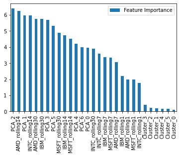

```python
rf2 = RandomForestClassifier(max_depth=6,n_estimators=200,random_state=0)
rf2.fit(X_train_full, y_train)

# predict probabilities
prediction_train = rf2.predict(X_train_full)
prediction_valid = rf2.predict(X_test_full)

print_scores(prediction_train,prediction_valid,y_train,y_test)

pd.DataFrame({'Feature Importance':rf2.feature_importances_*100},index=X_train_full.columns).sort_values('Feature Importance',ascending=False).plot.bar()
plt.show()
```

As we can see above, the Clusters are not very useful in determining whether INTC stocks will go up or not (averaged over the next 30 days). We will only include the PCA features along with the important variables.

## 4. Parameter Optimization

Let us begin by optimizing all the parameters of each model to prevent over fitting. We can use accuracy measures on the train and test set to find the right parameters to minimize overfitting.

```python
#Lets bundle up the train-test split into a single object for simplicity
split_data = (X_train_PCA,y_train,X_test_PCA,y_test)

####### HELPER FUNCTIONS ##############
#Make a function that takes in the train-test splits, the model and returns
#an accuracy score for the test and train set
def AccuracyScore(split_data,clf_model,score_type = 'Accuracy'):
    X_train,y_train,X_test,y_test = split_data
    #Run the model and test it
    clf_model.fit(X_train, y_train)
    prediction_train = clf_model.predict(X_train)
    prediction_valid = clf_model.predict(X_test)

    #Return Results as a list of dictionaries
    if score_type == 'Accuracy':
        return_dict = {};
        return_dict['Train Accuracy'] = accuracy_score(y_train,prediction_train);
        return_dict['Test Accuracy'] = accuracy_score(y_test,prediction_valid);
    elif score_type == 'AUC':
        return_dict = {};
        return_dict['Train AUC'] = AUCscore(y_train,prediction_train);
        return_dict['Test AUC'] = AUCscore(y_test,prediction_valid);

    return return_dict

#Make a function that takes in a list of models and the train-test split
#a list where the first element is a dictionary of parameters, the second element is the model

def AccuracyResults(model_func,changing_params,fixed_params,split_data,score_type='Accuracy'):
    models = [(params,model_func(**{**params,**fixed_params})) for params in changing_params]
    results = pd.DataFrame([{**AccuracyScore(split_data,model[1],score_type),**model[0]} for model in models])
    return results

def ParameterPlot(model_func,changing_params,fixed_params,split_data,model_name,score_type='Accuracy'):
    param_name = list(changing_params[0].keys())[0]
    results = AccuracyResults(model_func,changing_params,fixed_params,split_data,score_type)
    results = results.set_index(param_name)
    results.plot(ylim=(0,1),title=model_name + ': ' + score_type + ' vs. '+ param_name)
    plt.show()
```

### Random Forest

#### On just important variables

We will start by looking at the parameters on *just* the important variables, it'd be interesting to see whether adding the PCA variables changes the optimal parameters.

We would like to optimize `max_depth` for our random forest and play with the `n_estimators`. We will be keeping a close eye on train and test accuracy and notice that any point at which they start diverging is a good sign that over-fitting has begun to happen. The optimal values parameters will be those that have the highest test accuracy without entering the over-fitting regime.

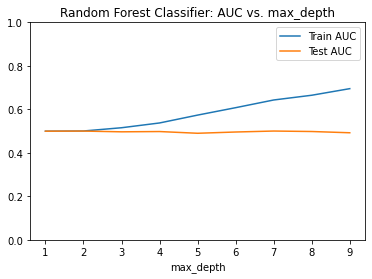

```python
split_data = (X_train_imp,y_train,X_test_imp,y_test)

changing_params = [{'max_depth':i} for i in range(1,10)]
fixed_params = {'n_estimators':10,'random_state':0}
model_func = RandomForestClassifier

ParameterPlot(model_func,changing_params,fixed_params,split_data,'Random Forest Classifier','AUC')
```

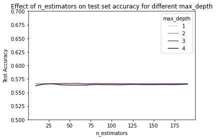

```python
changing_params = [{'max_depth':i,'n_estimators':j} for i in range(1,5) for j in range(10,200,10)]
fixed_params = {'random_state':0}
model_func = RandomForestClassifier

results = AccuracyResults(model_func,changing_params,fixed_params,split_data)

sns.lineplot(data=results,x='n_estimators',y='Test Accuracy',hue='max_depth')
plt.ylim((0.5,0.7))
plt.title("Effect of n_estimators on test set accuracy for different max_depth")
plt.show()
```

**For Random Forest on the non-engineered variables**, we find that the best estimators are:

- max_depth = 2
- The accuracy is not sensitive to the number of estimators in the Random Forest model. We can set this to 20.

#### On important values + PCA values

We only look at the features we considered "important" and append to them the PCA variables we computed. To check if the PCA values help.

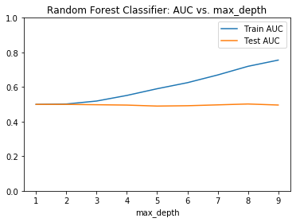

```python
#Using this function to find the change in accuracy for Random Forest
split_data = (X_train_PCA_full,y_train,X_test_PCA_full,y_test)

changing_params = [{'max_depth':i} for i in range(1,10)]
fixed_params = {'n_estimators':100,'random_state':0}
model_func = RandomForestClassifier

ParameterPlot(model_func,changing_params,fixed_params,split_data,'Random Forest Classifier','AUC')
```

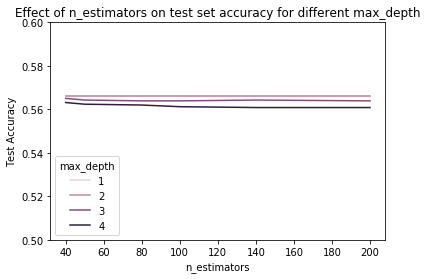

```python
changing_params = [{'max_depth':i,'n_estimators':j} for i in range(1,5) for j in [40,50,80,100,140,200]]
fixed_params = {'random_state':0}
model_func = RandomForestClassifier

results = AccuracyResults(model_func,changing_params,fixed_params,split_data)

sns.lineplot(data=results,x='n_estimators',y='Test Accuracy',hue='max_depth')
plt.ylim((0.5,0.6))
plt.title("Effect of n_estimators on test set accuracy for different max_depth")
plt.show()
```

For Random Forest on the engineered variables, we find that the best estimators are:

- max_depth = 2
- The accuracy is not sensitive to the number of estimators in the Random Forest model. We can set this to 20.

## 5. Ensemble and Stacking Methods

We will use a Voting Classifier to see if we can get better predictions by stacking our previously considered models. Weighting different classifiers could possibly give us more accurate results, we would like to see.

```python
from sklearn.ensemble import RandomForestClassifier
from sklearn.linear_model import LogisticRegression
from sklearn.ensemble import VotingClassifier
from sklearn.ensemble import StackingClassifier

estimators = [
    ('rf', RandomForestClassifier(n_estimators=100, max_depth = 1, random_state=0)),
    ('log_reg',LogisticRegression(max_iter = 1000,random_state=0)),
    ('dt',tree.DecisionTreeClassifier(max_depth=5,random_state=0))
]
clf = VotingClassifier(
    estimators=estimators, voting='soft', weights=[1,1,1]
)

split_data = (X_train_PCA_full,y_train,X_test_PCA_full,y_test)
print(AccuracyScore(split_data,clf))
print(AccuracyScore(split_data,clf,'AUC'))
```

```
{'Train Accuracy': 0.6174926156875615, 'Test Accuracy': 0.5700612557427259}
{'Train AUC': 0.5585031273804482, 'Test AUC': 0.5108139430103235}
```

Our voting classifier gives worse results than we thought, though it is a **slight** improvement over the random forest we started out with. We consider performing a Grid search to find optimal parameters for this ensemble method.

### Grid Search on ensemble classifier

```python
from sklearn.model_selection import GridSearchCV
from sklearn.model_selection import TimeSeriesSplit #To implement appropriate crossvalidation for Timeseries

estimators = [
    ('rf', RandomForestClassifier(n_estimators=100, max_depth = 1, random_state=0)),
    ('log_reg',LogisticRegression(max_iter = 1000,random_state=0)),
    ('dt',tree.DecisionTreeClassifier(max_depth=5,random_state=0))
]

clf = VotingClassifier(
    estimators=estimators, voting='soft', weights=[1,1,1]
)

param_grid = {
   'rf__max_depth': [1,2,3],
   'dt__max_depth': [2,3,5]}

X = df_PCA_full.drop('Price_Up',axis=1);
y = df_PCA_full['Price_Up']

Split_iterator = TimeSeriesSplit().get_n_splits(X,y)

search = GridSearchCV(clf, param_grid, cv=Split_iterator).fit(X, y)

print(AccuracyScore(split_data,search))
print(AccuracyScore(split_data,search,'AUC'))
```

```
{'Train Accuracy': 0.5938628158844765, 'Test Accuracy': 0.5643185298621746}
{'Train AUC': 0.5293027066414964, 'Test AUC': 0.5030587089509084}
```

The grid search has used it's own scoring function on the cross validation datasets to infer a parameter for the voting classifier. However, when judged against the simple 70-30 train-test split we have been using, the grid search algorithm finds parameters for the voting classifier that performs worse than the voting classifier we set before.

Hence, our best model so far is a Voting Classifier with our random forest, logistic regression and decision tree classifiers as its estimators.

## 6. Conclusion

### Improvements and Next Steps

#### 1. Avoid leakage

While we have used other ways to prevent leakage (e.g. Having only one train-test split with no time period overlap), in order to further backtest these results and confirm that we are avoiding leakage, our next step would be to use modern cross validation techniques. According to Advances in Financial Machine Learning by Marcos Lopez De Prado, standard cross validation is not entirely sufficent in practice. The solution is to use a 'purged' k-fold cross validation, which reduces leakage by 'purging' all observations from the training set that overlap with the time period including in the testing set. There is an additional step in using an 'embargo', which removes some observations immediately before and after the test set to avoid any additional leakage. These modern solutions are difficult to implement but offer the best success in practice.

#### 2. Selection criteria

One of the limitations of our approach is that the selection of predictors is ad hoc. Although the correlation between the stock price of INTC and predictors are all positive, there might be some better candidates for our predictors. Also, if we want to use our model to predict other stocks price, we need to set a criteria to select the predictors more objectively. One possible way is that only includes the highly correlated(e.g. correlation coefficient>0.5) stock with target variable as predictor.

#### 3. Stationariness of time series data

To examine whether the target variable/predictors data is stationary or not. A stationary time series data is one whose statistical properties are all constant over time, we could be fairly confident that our model will work nicely when new, unseen, stationary data arrive. On the other hand, a nonstationary time series data may have a stochastic trend, which means there may be a huge different between the data we used to build our model and the unseen data.

#### 4. Combining data from different datasets

We can augment our current dataset by including financial news sentiment data going back to the 1980s. We can find financial news about a stock, and it's corresponding sentiment and how it affects the stock market. This may give new information for our models to reason based off of. This could be a promising direction but needs a large project of compiling news data.